# RTI - Data Science Exercise

Tanner Robart

2/20/17

## Report Summary

This is an analysis of the Census data from 1996, looking at which demographic variables have the greatest effect on whether an individual earns over $50,000 anually. A logistic regression model found demographic features such as age, sex, race and education level to be effective predictive variables.

### The following is the exercise prompt:

- Write a SQL query that creates a consolidated dataset from the normalized tables in the database. In other words, write a SQL query that “flattens” the database to a single table.
- Export the “flattened” table to a CSV file.
- Import the “flattened” table (or CSV file) into your open source analytic environment of choice (R, Python, Java, etc.) and stage it for analysis.
- Perform some simple exploratory analysis and generate summary statistics to get a sense of what is in the data. You should commit any useful or informative exloratory code.
- Split the data into training, validation, and test data sets.
- Develop a model that predicts whether individuals, based on the census variables provided, make over $50,000/year. Use over_50k as the target variable.
- Commit enough code to reproduce your full model selection process, including your final model and all models developed along the way.
- Generate a chart that you feel conveys 1 or more important relationships in the data.
- Describe your methodology and results in 1/2 page of writing.
- Include the chart(s) generated in Step 7 as part of your write-up. If neccesary, explain how the chart(s) informs your approach.

## Steps 1 and 2

#### Write a SQL query that creates a consolidated dataset from the normalized tables in the database. In other words, write a SQL query that “flattens” the database to a single table.

The following SQL query provides a flattened table that we can export to .csv easily.

```
SELECT
    recs.id,
    recs.age,
    s.name as Sex,
    race.name as Race,
    w.name as Workclass,
    recs.hours_week as Hours_Worked,
    edu.name as Education_Level,
  recs.education_num,
  c.name as Country,
    o.name as Occupation,
    rel.name as Relationship,
  m.name as Marital_Status,
    recs.capital_gain as Capital_Gain,
    recs.capital_loss as Capital_Loss,
    recs.over_50k as Over_50k

FROM 'records' recs

join countries c
    on c.id = recs.country_id
join workclasses w
    on w.id = recs.workclass_id
join marital_statuses m
    on m.id = recs.marital_status_id
join education_levels edu
    on edu.id = recs.education_level_id
join occupations o
    on o.id = recs.occupation_id
join sexes s
    on s.id = recs.sex_id
join races race
    on race.id = recs.race_id
join relationships rel
    on rel.id = recs.relationship_id
```

This query gives us a single table that we can now export to csv and load into R. We do this and take a first look at some summary statistics for the data.

```r
setwd("C:/Users/trobart/Desktop/data-scientist-exercise01") #setting working directory, replace with your own filepath
census_data <- fread("flattened_census_data.csv") # read in csv file as data.table object
census_data[census_data == '?'] <- NA #replacing '?' entries with NA
census_data$Over_50k <- factor(census_data$Over_50k) #making sure Over-50k is treated as a factor
head(census_data)
```

```
##    id age    Sex  Race        Workclass Hours_Worked Education_Level
## 1:  1  39   Male White        State-gov           40       Bachelors
## 2:  2  50   Male White Self-emp-not-inc           13       Bachelors
## 3:  3  38   Male White          Private           40         HS-grad
## 4:  4  53   Male Black          Private           40            11th
## 5:  5  28 Female Black          Private           40       Bachelors
## 6:  6  37 Female White          Private           40         Masters
##    education_num       Country        Occupation  Relationship
## 1:            13 United-States      Adm-clerical Not-in-family
## 2:            13 United-States   Exec-managerial       Husband
## 3:             9 United-States Handlers-cleaners Not-in-family
## 4:             7 United-States Handlers-cleaners       Husband
## 5:            13          Cuba    Prof-specialty          Wife
## 6:            14 United-States   Exec-managerial          Wife
##        Marital_Status Capital_Gain Capital_Loss Over_50k
## 1:      Never-married         2174            0        0
## 2: Married-civ-spouse            0            0        0
## 3:           Divorced            0            0        0
## 4: Married-civ-spouse            0            0        0
## 5: Married-civ-spouse            0            0        0
## 6: Married-civ-spouse            0            0        0
```

```r
summary(census_data)
```

```
##        id             age            Sex                Race
##  Min.   :    1   Min.   :17.00   Length:48842       Length:48842
##  1st Qu.:12211   1st Qu.:28.00   Class :character   Class :character
##  Median :24422   Median :37.00   Mode  :character   Mode  :character
##  Mean   :24422   Mean   :38.64
##  3rd Qu.:36632   3rd Qu.:48.00
##  Max.   :48842   Max.   :90.00
##   Workclass          Hours_Worked   Education_Level    education_num
##  Length:48842       Min.   : 1.00   Length:48842       Min.   : 1.00
##  Class :character   1st Qu.:40.00   Class :character   1st Qu.: 9.00
##  Mode  :character   Median :40.00   Mode  :character   Median :10.00
##                     Mean   :40.42                      Mean   :10.08
##                     3rd Qu.:45.00                      3rd Qu.:12.00
##                     Max.   :99.00                      Max.   :16.00
##    Country           Occupation        Relationship
##  Length:48842       Length:48842       Length:48842
##  Class :character   Class :character   Class :character
##  Mode  :character   Mode  :character   Mode  :character
##
##
##
##  Marital_Status      Capital_Gain    Capital_Loss    Over_50k
##  Length:48842       Min.   :    0   Min.   :   0.0   0:37155
##  Class :character   1st Qu.:    0   1st Qu.:   0.0   1:11687
##  Mode  :character   Median :    0   Median :   0.0
##                     Mean   : 1079   Mean   :  87.5
##                     3rd Qu.:    0   3rd Qu.:   0.0
##                     Max.   :99999   Max.   :4356.0
```

This summary provides a quick look at the distributions of the continuous variables. It also shows us that the count of Over_50k is 11687 out of 48842, or **~23.9%** of our census_dataset make over 50k. But this is a little messy to read and doesn’t provide many useful summary statistics, so lets take a look using the psych package’s describe() method.

### Additonal summary statistics

```r
describe(census_data)
```

```
##                  vars     n     mean       sd  median  trimmed      mad
## id                  1 48842 24421.50 14099.62 24421.5 24421.50 18103.29
## age                 2 48842    38.64    13.71    37.0    37.74    14.83
## Sex*                3 48842      NaN       NA      NA      NaN       NA
## Race*               4 48842      NaN       NA      NA      NaN       NA
## Workclass*          5 46043      NaN       NA      NA      NaN       NA
## Hours_Worked        6 48842    40.42    12.39    40.0    40.54     4.45
## Education_Level*    7 48842      NaN       NA      NA      NaN       NA
## education_num       8 48842    10.08     2.57    10.0    10.19     1.48
## Country*            9 47985      NaN       NA      NA      NaN       NA
## Occupation*        10 46033      NaN       NA      NA      NaN       NA
## Relationship*      11 48842      NaN       NA      NA      NaN       NA
## Marital_Status*    12 48842      NaN       NA      NA      NaN       NA
## Capital_Gain       13 48842  1079.07  7452.02     0.0     0.00     0.00
## Capital_Loss       14 48842    87.50   403.00     0.0     0.00     0.00
## Over_50k*          15 48842     1.24     0.43     1.0     1.17     0.00
##                  min   max range  skew kurtosis    se
## id                 1 48842 48841  0.00    -1.20 63.80
## age               17    90    73  0.56    -0.18  0.06
## Sex*             Inf  -Inf  -Inf    NA       NA    NA
## Race*            Inf  -Inf  -Inf    NA       NA    NA
## Workclass*       Inf  -Inf  -Inf    NA       NA    NA
## Hours_Worked       1    99    98  0.24     2.95  0.06
## Education_Level* Inf  -Inf  -Inf    NA       NA    NA
## education_num      1    16    15 -0.32     0.63  0.01
## Country*         Inf  -Inf  -Inf    NA       NA    NA
## Occupation*      Inf  -Inf  -Inf    NA       NA    NA
## Relationship*    Inf  -Inf  -Inf    NA       NA    NA
## Marital_Status*  Inf  -Inf  -Inf    NA       NA    NA
## Capital_Gain       0 99999 99999 11.89   152.67 33.72
## Capital_Loss       0  4356  4356  4.57    20.01  1.82
## Over_50k*          1     2     1  1.22    -0.51  0.00
```

This table is easier to read and includes standard deviation, skew, se, and kurtosis information. Many of the categorical variables have NA for their summary statistics because they are not ordinal or continuous. Lets also examine how much missing data we have.

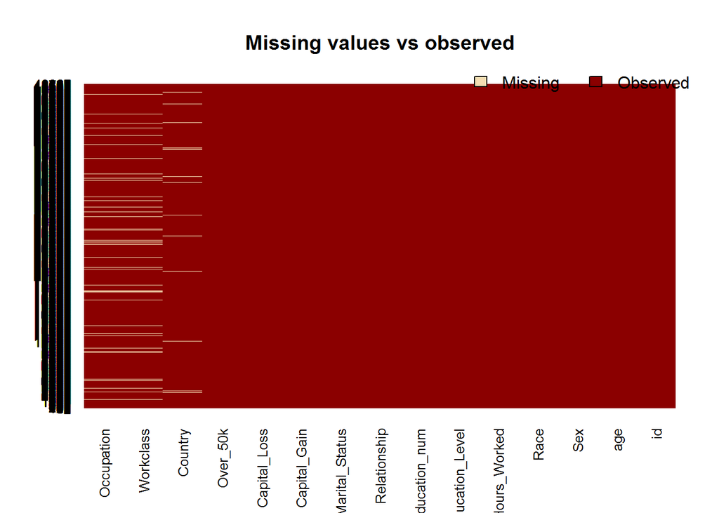

```r
library(Amelia)
missmap(census_data, main = "Missing values vs observed")
```

It looks like Occupation and Workclass are the only variables with significant missing values, and we’ll keep that in mind during feature selection later. Now lets take a closer look at our target variable and its relationship to the other features.

### Examining initial relationships between variables using a matrix plot

[figure not shown]

```r
#pairs for other features that are difficult to read in this format
#ggpairs(census_data, columns = c('Workclass',"Relationship", 'Occupation','Over_50k'), axisLabels="show")
```

#### Over 50k proportion

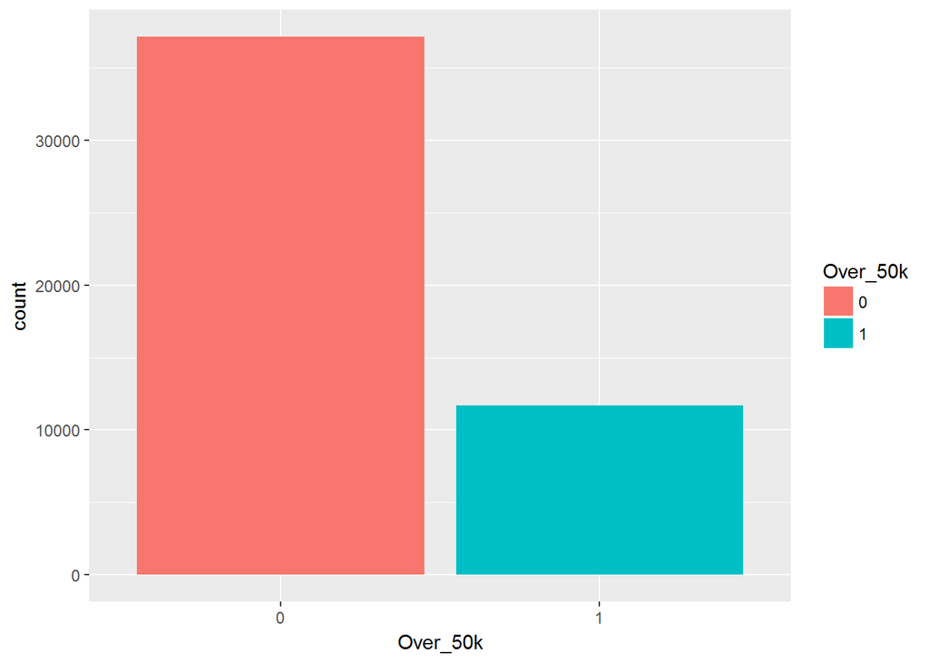

```r
p1 <- ggplot(census_data, aes(Over_50k, fill = Over_50k)) +geom_bar()
print(p1)
```

### Age vs. Over_50k

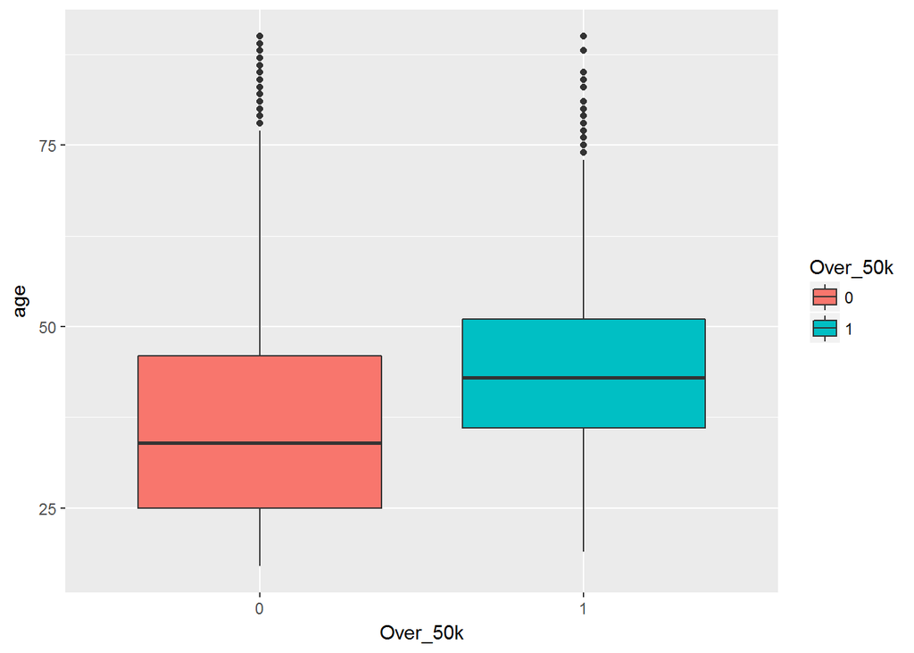

```r
p2 <- ggplot(census_data, aes(x = Over_50k, y = age, fill = Over_50k)) + geom_boxplot()
print(p2)
```

#### Education

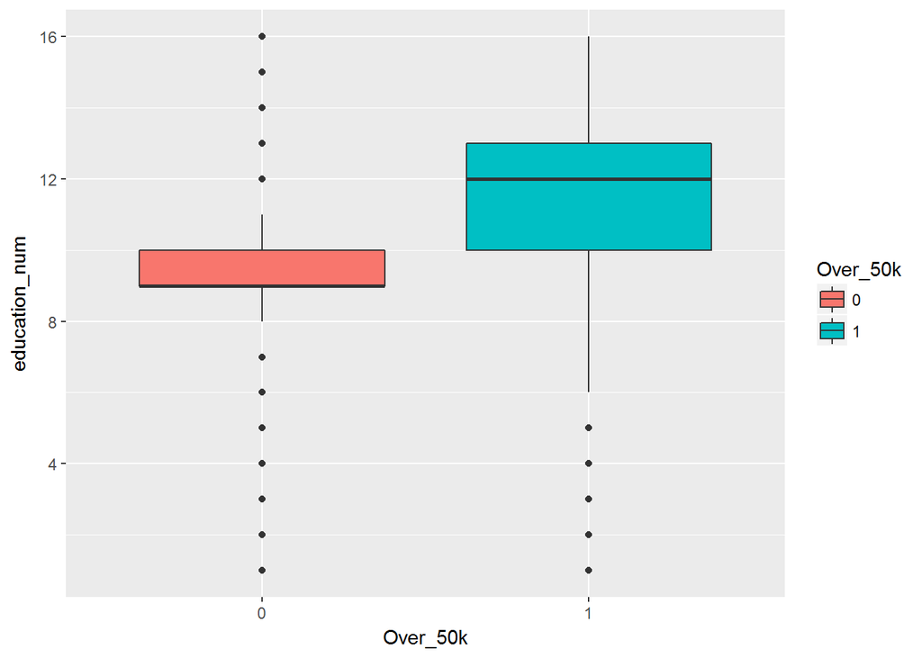

```r
p3 <- ggplot(census_data, aes(x = Over_50k, y = education_num, fill = Over_50k)) + geom_boxplot()
print(p3)
```

We can clearly see that education has a strong relationship with earning over 50k. Lets take a look at the individual category breakdowns.

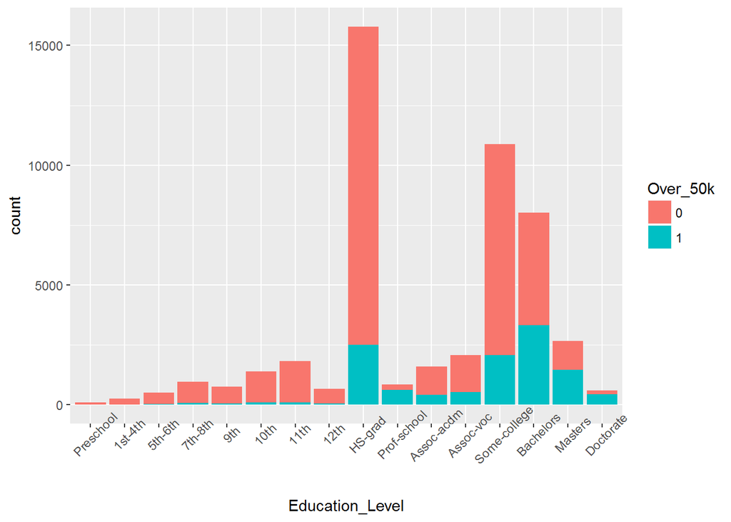

```r
census_data$Education_Level <- factor(census_data$Education_Level, levels=c("Preschool","1st-4th", "5th-6th", "7th-8th", "9th", "10th", "11th", "12th", "HS-grad", "Prof-school", "Assoc-acdm", "Assoc-voc", "Some-college", "Bachelors", "Masters", "Doctorate"))  #re-ordering factor levels to reflect a more sensible linear order

p4 <- ggplot(census_data, aes(x = Education_Level, fill = Over_50k )) +
  geom_bar() +
  theme( axis.text.x = element_text(angle=45))

print(p4)
```

Education level seems to be a very good indicator of earning over 50k, with proportion of over_50k increasing as the education level increases. Lets also take a look at education number to see if it contains any other useful information not included in education level.

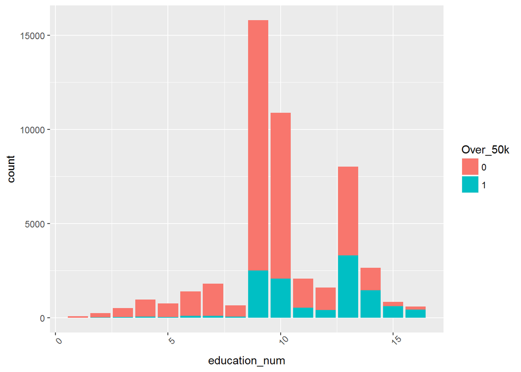

```r
p5 <- ggplot(census_data, aes(x = education_num, fill = Over_50k )) +
  geom_bar() +
  theme( axis.text.x = element_text(angle=45))
print(p5)
```

The order of the values in education num differ from what my intuition of the proper order of levels of education are, but it appears this feature contains all the same information as education level. As such, we will want to remove one or the other to avoid co-linearity of features when fitting a model.

#### Hours Worked

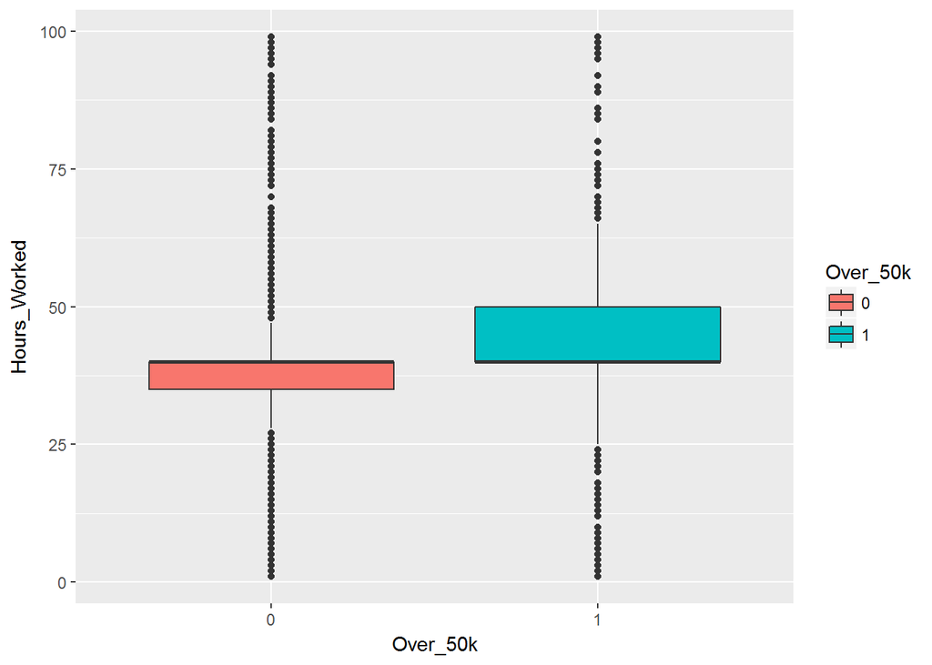

```r
p6 <- ggplot(census_data, aes(x = Over_50k, y = Hours_Worked, fill = Over_50k)) + geom_boxplot()
print(p6)
```

We can see there seems to be a signifcant effect of hours worked on whether an individual earns over 50k or not. Lets take a closer look at the breakdown of hours worked.

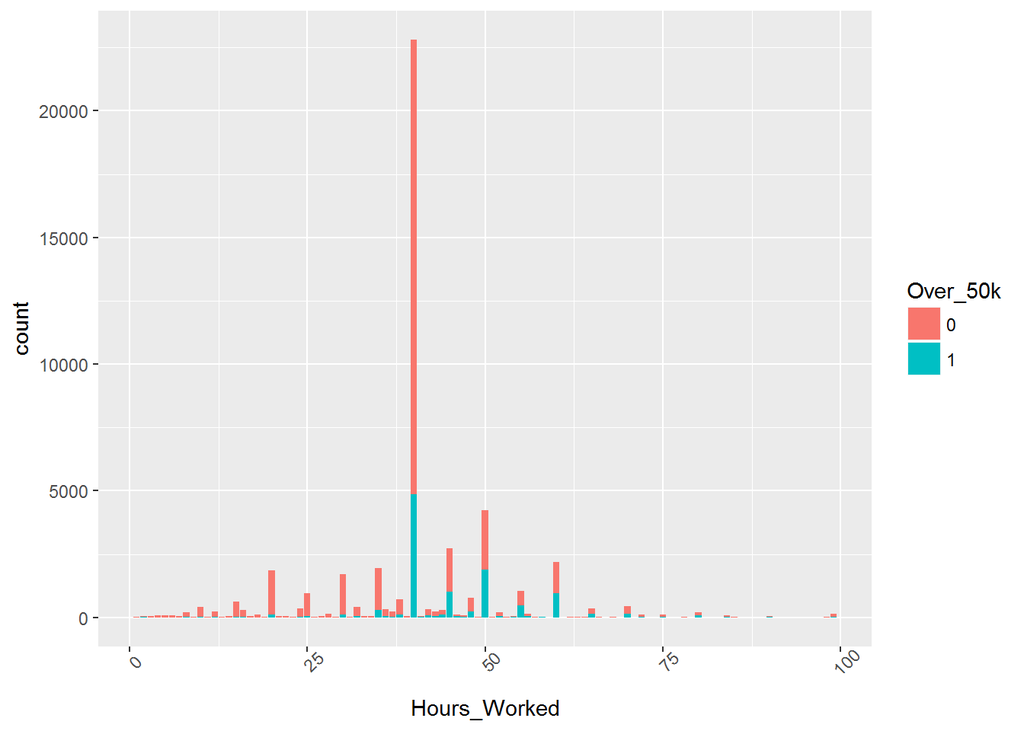

```r
p6 <- ggplot(census_data, aes(x = Hours_Worked, fill = Over_50k)) +
  geom_bar() +
  theme( axis.text.x = element_text(angle=45))

print(p6)
```

#### Workclass

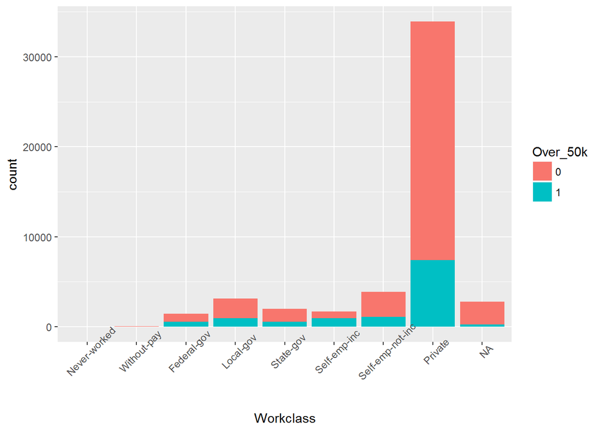

```r
census_data$Workclass <- factor(census_data$Workclass, levels=c( "NA","Never-worked", "Without-pay","Federal-gov","Local-gov", "State-gov" , "Self-emp-inc", "Self-emp-not-inc", "Private"))
p3 <- ggplot(census_data, aes(x = Workclass, fill = Over_50k)) +
  geom_bar() +
  theme( axis.text.x = element_text(angle=45))

print(p3)
```

This plot makes it clear that the working class with the greatest proportion of over 50k earners is in the self-employed-inc group. But we have by far the most entries from the Private catagory, with more over_50k earners than any single other workclass including both over and under 50k earners. There are only two entries for Never-worked, and so when fitting models, R does not like when the training set does not contain this factor level, so we will remove it without any issues to model performance.

```r
census_data[Workclass == "Never-worked"] <- NA
```

#### Occupation

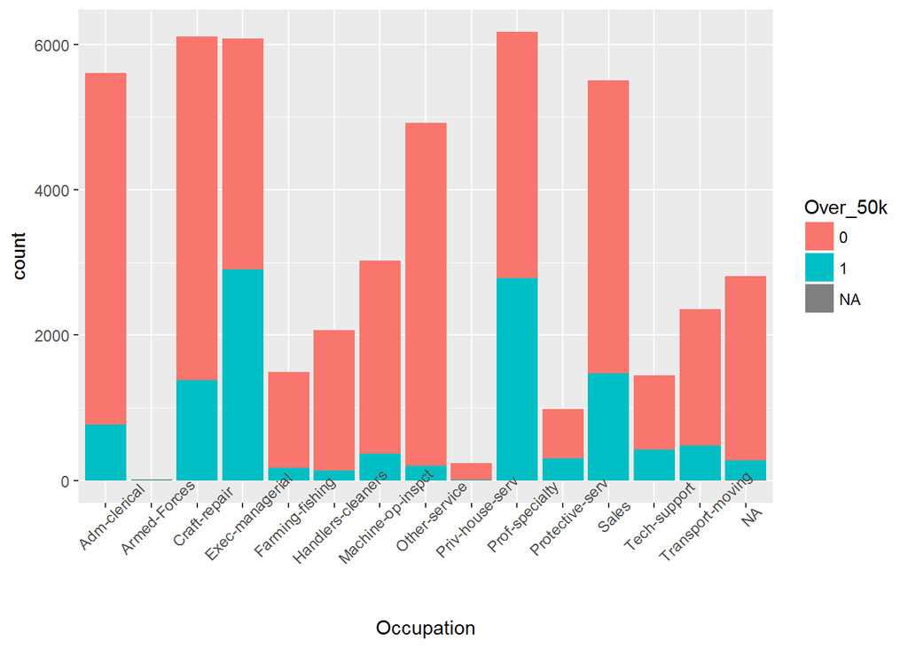

```r
#census_data$Occupation <- factor(census_data$Occupation, levels=c()  #re-ordering factor levels to reflect a more sensible order

p5 <- ggplot(census_data, aes(x = Occupation, fill = Over_50k )) +
  geom_bar() +
  theme( axis.text.x = element_text(angle=45))

print(p5)
```

The occupations with the greatest proportion of over 50k earners are Exec-managerial and Prof-speciality, which makes sense because executive managerial positions generally earn the most within a company, and speciality professionals could charge whatever the want for an uncommon skill or service.

#### Relationship

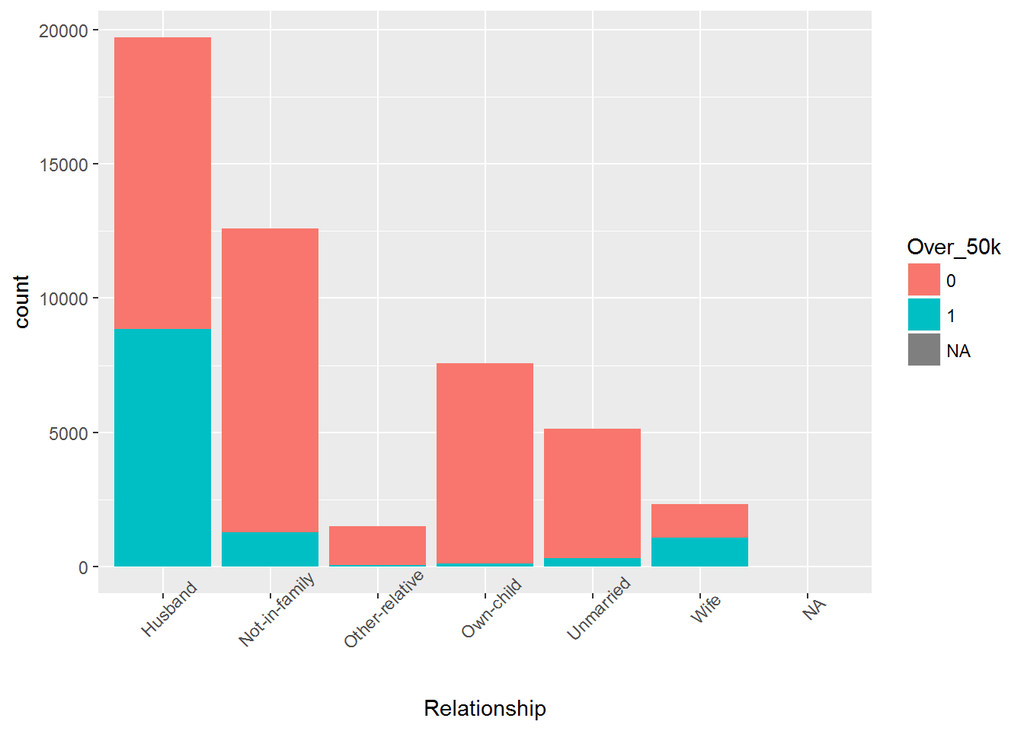

```r
p5 <- ggplot(census_data, aes(x = Relationship, fill = Over_50k )) +
  geom_bar() +
  theme( axis.text.x = element_text(angle=45))

print(p5)
```

Examining the Relationship variable, we see clearly that husbands and wives are much more likely to earn over 50k compared to the other categories. This may be a good correlated feature in our models, so we should definitely use it, and maybe even split it into a binary of is wife/husband or not.

#### Country of Origin

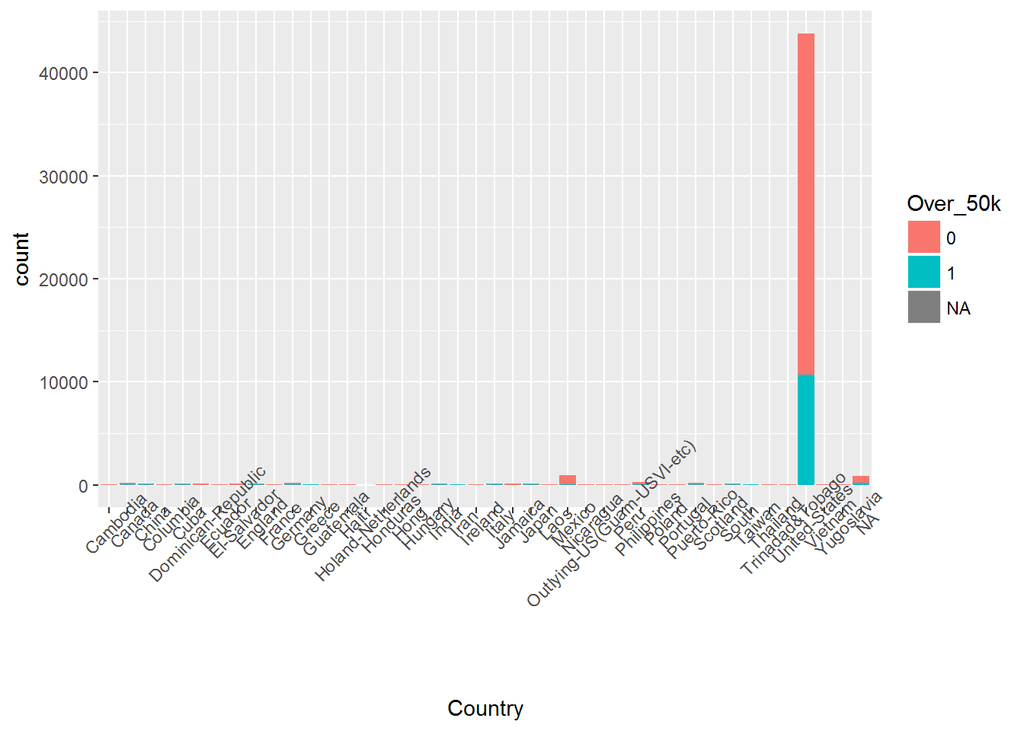

```r
p5 <- ggplot(census_data, aes(x = Country, fill = Over_50k )) +
  geom_bar() +
  theme( axis.text.x = element_text(angle=45))

print(p5)
```

The overwhelming majority of observations in our data are from the United States, which provides little explanatory power as a feature, so we may wish to remove it from our training features

#### Capital Gain

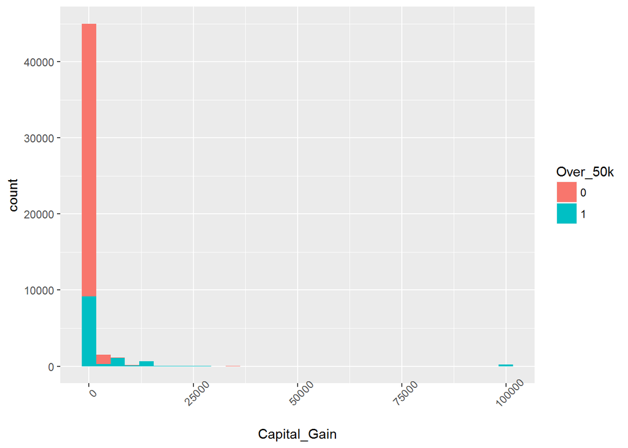

```r
p6 <- ggplot(census_data, aes(Capital_Gain, fill = Over_50k)) +
  geom_histogram() +
  theme( axis.text.x = element_text(angle=45))

print(p6)
```

This one is very interesting, it appears more than **90%** of rows in our data have a value of 0 for capital gains, which is significant bias for this feature. However all rows above a certain capital_gain value are over_50k earners, which may be a useful predictive variable. So instead, it might be useful to make a new feature of only capital gains > 0. This feature might improve model performance over the regular capital gain.

#### Capital Loss

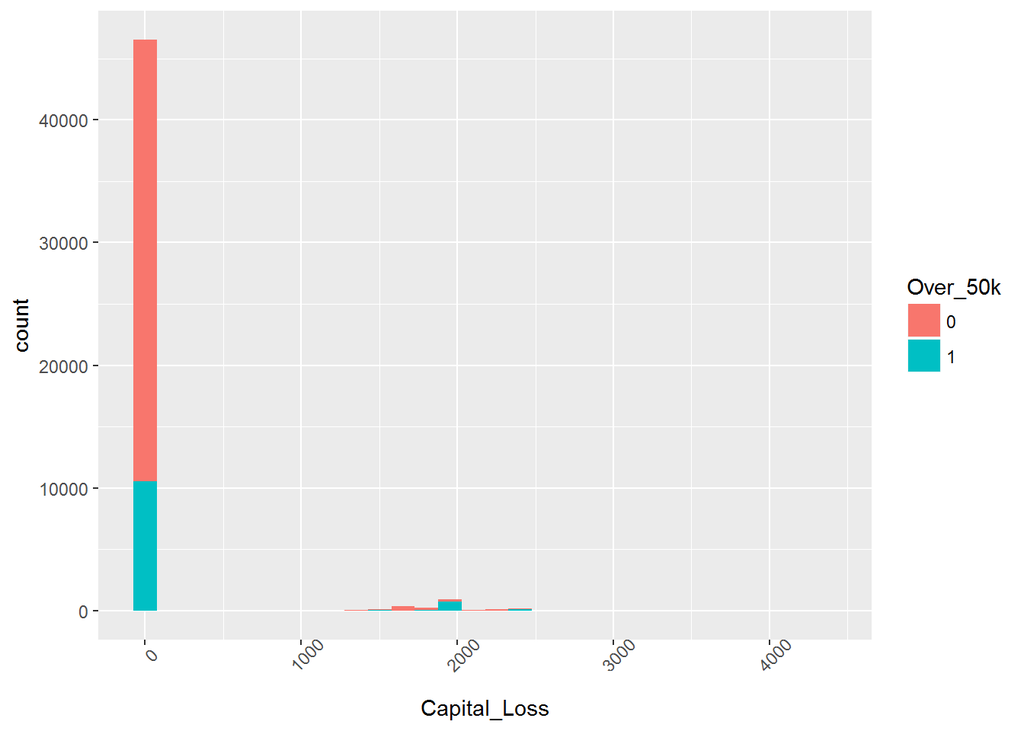

```r
p5 <- ggplot(census_data, aes(Capital_Loss, fill = Over_50k)) +
  geom_histogram() +
  theme( axis.text.x = element_text(angle=45))

print(p5)
```

The same is true of our Capital_Loss feature as it is of our Capital_Gain, so we might want to consider also throwing out the Capital_Loss values of 0, and only using those > 0 as a model feature.

## Split the data into training, validation, and test data sets.

```r
set.seed(1111) # setting seed for reproducibility
sub <- sample(nrow(census_data), floor(nrow(census_data) * 0.8)) # setting a 80/20 split for train/test
training <- census_data[sub, ]
testing <- census_data[-sub, ]
```

## Create a model that predicts whether individuals, based on the census variables provided, make over $50,000/year.

### Logistic Regression Model

```r
mylogit <- glm(Over_50k ~ ., data = training, family = "binomial")
summary(mylogit)
```

[output not shown]

[output cut: 45 more lines]

```
## Marital_StatusSeparated
## Marital_StatusWidowed
## Capital_Gain                        ***
## Capital_Loss                        ***
## ---
## Signif. codes:  0 '***' 0.001 '**' 0.01 '*' 0.05 '.' 0.1 ' ' 1
##
## (Dispersion parameter for binomial family taken to be 1)
##
##     Null deviance: 29839  on 24803  degrees of freedom
## Residual deviance: 17268  on 24765  degrees of freedom
##   (14269 observations deleted due to missingness)
## AIC: 17346
##
## Number of Fisher Scoring iterations: 11
```

```r
anova(mylogit, test="Chisq")
```

```
## Analysis of Deviance Table
##
## Model: binomial, link: logit
##
## Response: Over_50k
##
## Terms added sequentially (first to last)
##
##
##                 Df Deviance Resid. Df Resid. Dev Pr(>Chi)
## NULL                            24803      29839
## id               1     0.13     24802      29839   0.7194
## age              1  1736.39     24801      28102   <2e-16 ***
## Sex              1  1286.76     24800      26816   <2e-16 ***
## Race             4   158.47     24796      26657   <2e-16 ***
## Workclass        6   327.96     24790      26329   <2e-16 ***
## Hours_Worked     1   910.42     24789      25419   <2e-16 ***
## Education_Level  3  2255.92     24786      23163   <2e-16 ***
## Occupation      13  1003.14     24773      22160   <2e-16 ***
## Marital_Status   6  3009.54     24767      19150   <2e-16 ***
## Capital_Gain     1  1600.48     24766      17550   <2e-16 ***
## Capital_Loss     1   281.26     24765      17269   <2e-16 ***
## ---
## Signif. codes:  0 '***' 0.001 '**' 0.01 '*' 0.05 '.' 0.1 ' ' 1
```

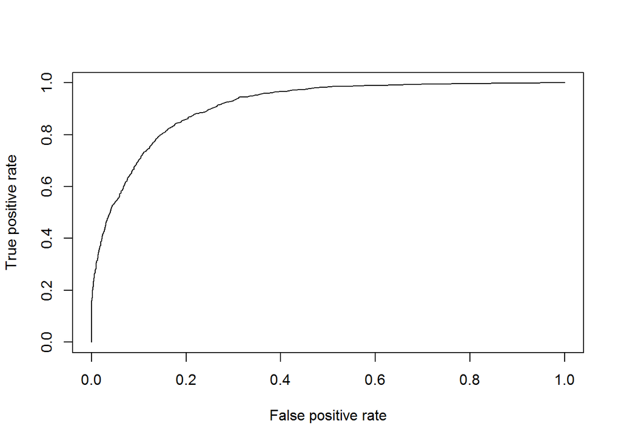

```r
#testing and validation
predictions <- predict(mylogit, testing, type = "response")
mylogitPredictions <- prediction(predictions, list(testing$Over_50k))


# ROC
mylogitROC <- performance(mylogitPredictions, 'tpr','fpr')
plot(mylogitROC)
```

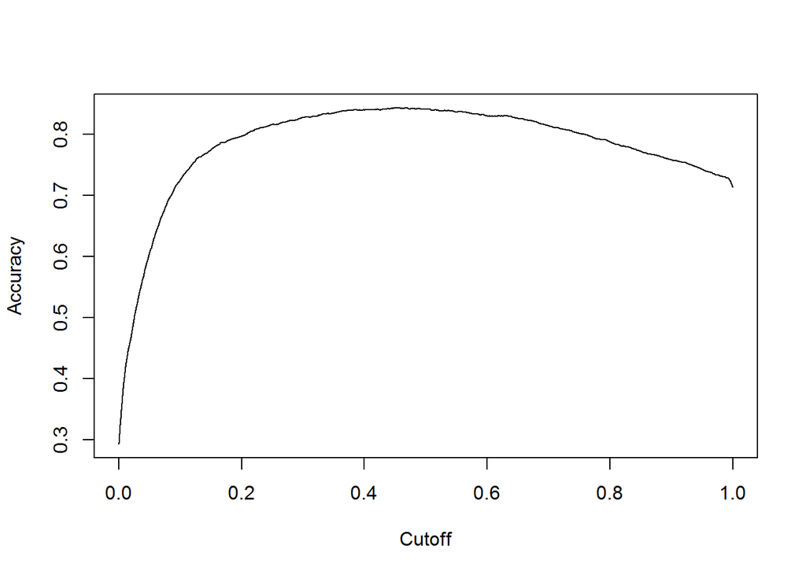

```r
mylogitACC <- performance(mylogitPredictions, 'acc')
plot(mylogitACC)
```

```r
# AUC
mylogitAUC <- unlist(performance(mylogitPredictions, 'auc')@y.values)
mylogitAUC
```

```
## [1] 0.9109134
```

```r
# determining cutoff to use from specificity and sensitivity


#cutoff using Youden J-statistic

 cutoff <- unlist(mylogitROC@alpha.values)[which.max(unlist(mylogitROC@y.values)+ ( 1 - unlist(mylogitROC@x.values) )-1)]

# cutoff <- .5 #using a default cutoff of .5 is reasonable and favors high accuracy, but the true positive and false positive rate tradeoff can be optimized to favor one over the other depending on the situation.


predicted <- ifelse(predictions >= cutoff, 1, 0)
mylogitConfusion <- table(testing$Over_50k, predicted)
logitTruePos <- mylogitConfusion[2,2]/sum(mylogitConfusion[2,])
logitTrueNeg <- mylogitConfusion[1,1]/sum(mylogitConfusion[1,])
logitAccuracy <-sum(mylogitConfusion[2,2],mylogitConfusion[1,1])/sum(mylogitConfusion)

logitTruePos
```

```
## [1] 0.8424544
```

```r
logitTrueNeg
```

```
## [1] 0.8233143
```

```r
logitAccuracy
```

```
## [1] 0.8289133
```

#### Naive Bayes

```r
myNaive <- naiveBayes(Over_50k ~ . , data=na.omit(training))
summary(myNaive)
```

```
##         Length Class  Mode
## apriori  2     table  numeric
## tables  11     -none- list
## levels   2     -none- character
## call     4     -none- call
```

#### Testing and Validation

```r
actual <- na.omit(testing)$Over_50k
predictions <- predict(myNaive, na.omit(testing), type="raw")[,2]
```

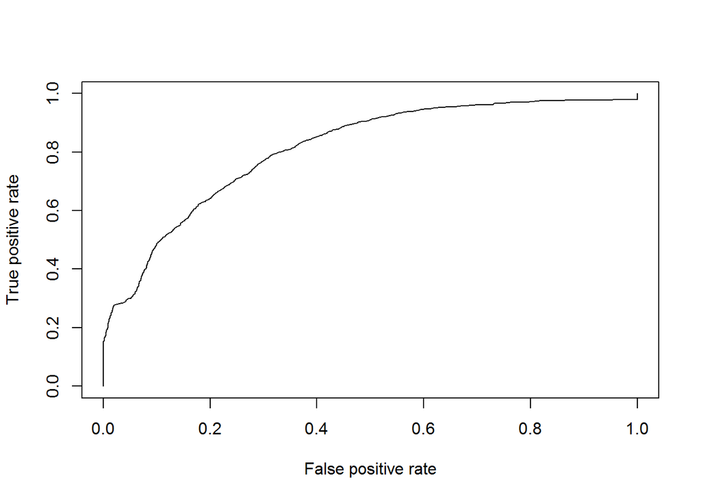

```r
naivePredictions <- prediction(predictions, actual)

#ROC
naiveROC <- performance(naivePredictions, 'tpr','fpr')
plot(naiveROC)
```

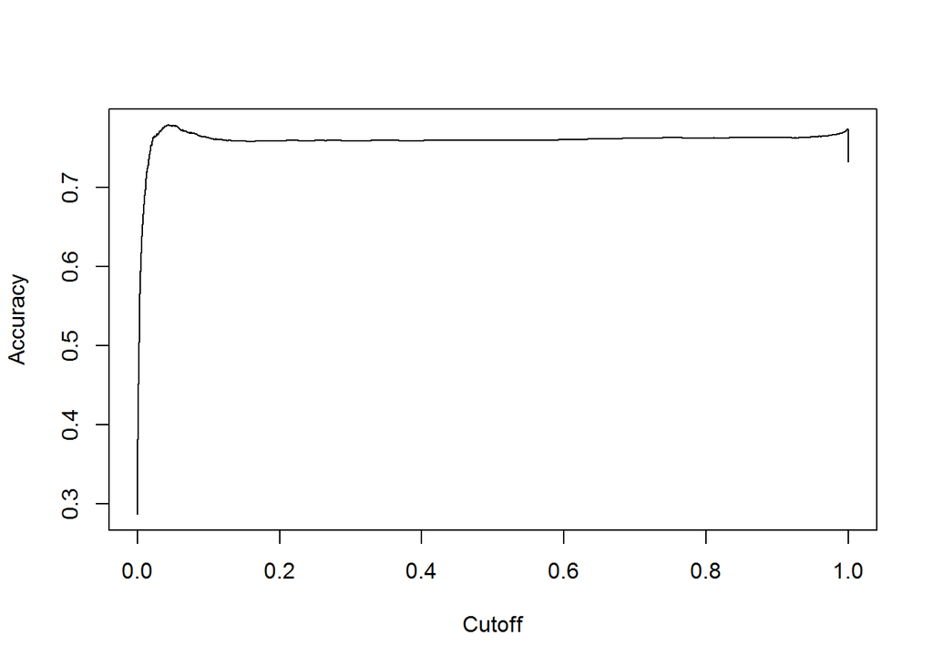

```r
cutoff <- unlist(naiveROC@alpha.values)[which.max(unlist(naiveROC@y.values)+ ( 1 - unlist(naiveROC@x.values) )-1)]

#Accuracy
naiveACC <- performance(naivePredictions, 'acc')
plot(naiveACC)
```

```r
#AUC
naiveAUC <- performance(naivePredictions, 'auc')
naiveAUC <- unlist(naiveAUC@y.values)
naiveAUC
```

```
## [1] 0.809982
```

```r
predicted <- ifelse(predictions >= cutoff, 1, 0)
naiveConfusion <- table(actual, predicted)
naiveTruePos <- naiveConfusion[2,2]/sum(naiveConfusion[2,])
naiveTrueNeg <- naiveConfusion[1,1]/sum(naiveConfusion[1,])
naiveAccuracy <-sum(naiveConfusion[2,2],naiveConfusion[1,1])/sum(naiveConfusion)

naiveTruePos
```

```
## [1] 0.7910448
```

```r
naiveTrueNeg
```

```
## [1] 0.6848
```

```r
naiveAccuracy
```

```
## [1] 0.7158797
```

#### Decision Tree

```r
mytree <- rpart(Over_50k ~ ., data=na.omit(training), method="anova")
summary(mytree)
```

```
## Call:
## rpart(formula = Over_50k ~ ., data = na.omit(training), method = "anova")
##   n= 24804
##
##           CP nsplit rel error    xerror        xstd
## 1 0.22696513      0 1.0000000 1.0000218 0.005902106
## 2 0.07755941      1 0.7730349 0.7731007 0.005869245
## 3 0.04823664      2 0.6954755 0.6991859 0.006715765
## 4 0.02612378      3 0.6472388 0.6509432 0.006493231
## 5 0.01731094      4 0.6211150 0.6236698 0.006374825
## 6 0.01370890      5 0.6038041 0.6060482 0.006357804
## 7 0.01044642      6 0.5900952 0.5941870 0.006311781
## 8 0.01000000      7 0.5796488 0.5833431 0.006333766
##
## Variable importance
##  Marital_Status      Occupation    Capital_Gain             Sex
##              33              17              13              12
##             age    Hours_Worked Education_Level       Workclass
##              11               5               4               3
##    Capital_Loss
##               2
##
## Node number 1: 24804 observations,    complexity param=0.2269651
##   mean=1.289268, MSE=0.205592
##   left son=2 (13174 obs) right son=3 (11630 obs)
##   Primary splits:
##       Marital_Status  splits as  LRRLLLL, improve=0.22696510, (0 missing)
##       Capital_Gain    < 5119   to the left,  improve=0.13900590, (0 missing)
##       age             < 29.5   to the left,  improve=0.10368330, (0 missing)
##       Occupation      splits as  LRLRLLLLLRRLLL, improve=0.09925360, (0 missing)
##       Education_Level splits as  LLRL, improve=0.07185628, (0 missing)
##   Surrogate splits:
##       Sex          splits as  LR, agree=0.698, adj=0.357, (0 split)
##       age          < 31.5   to the left,  agree=0.661, adj=0.277, (0 split)
##       Occupation   splits as  LRRRRLLLLRRLLR, agree=0.616, adj=0.180, (0 split)
##       Hours_Worked < 42.5   to the left,  agree=0.603, adj=0.154, (0 split)
##       Workclass    splits as  --RRLLRRL, agree=0.578, adj=0.101, (0 split)
##
## Node number 2: 13174 observations,    complexity param=0.04823664
##   mean=1.086306, MSE=0.07885757
```

[output cut: 72 more lines]

```
##   Primary splits:
##       age             < 28.5   to the left,  improve=0.03566809, (0 missing)
##       Education_Level splits as  LRRR, improve=0.03332205, (0 missing)
##       Occupation      splits as  LR-R-----RLLR-, improve=0.03029259, (0 missing)
##       Hours_Worked    < 32.5   to the left,  improve=0.02380303, (0 missing)
##       Capital_Gain    < 3120   to the right, improve=0.01332021, (0 missing)
##
## Node number 29: 581 observations
##   mean=1.932874, MSE=0.06261979
##
## Node number 56: 522 observations
##   mean=1.264368, MSE=0.1944775
##
## Node number 57: 5571 observations
##   mean=1.598456, MSE=0.2403064
```

```r
printcp(mytree)
```

```
##
## Regression tree:
## rpart(formula = Over_50k ~ ., data = na.omit(training), method = "anova")
##
## Variables actually used in tree construction:
## [1] age            Capital_Gain   Capital_Loss   Marital_Status
## [5] Occupation
##
## Root node error: 5099.5/24804 = 0.20559
##
## n= 24804
##
##         CP nsplit rel error  xerror      xstd
## 1 0.226965      0   1.00000 1.00002 0.0059021
## 2 0.077559      1   0.77303 0.77310 0.0058692
## 3 0.048237      2   0.69548 0.69919 0.0067158
## 4 0.026124      3   0.64724 0.65094 0.0064932
## 5 0.017311      4   0.62112 0.62367 0.0063748
## 6 0.013709      5   0.60380 0.60605 0.0063578
## 7 0.010446      6   0.59010 0.59419 0.0063118
## 8 0.010000      7   0.57965 0.58334 0.0063338
```

```r
print(mytree)
```

```
## n= 24804
##
## node), split, n, deviance, yval
##       * denotes terminal node
##
##  1) root 24804 5099.503000 1.289268
##    2) Marital_Status=Divorced,Married-spouse-absent,Never-married,Separated,Widowed 13174 1038.870000 1.086306
##      4) Capital_Gain< 7055.5 12871  786.048500 1.065341 *
##      5) Capital_Gain>=7055.5 303    6.838284 1.976898 *
##    3) Marital_Status=Married-AF-spouse,Married-civ-spouse 11630 2903.224000 1.519175
##      6) Occupation=Craft-repair,Farming-fishing,Handlers-cleaners,Machine-op-inspct,Other-service,Priv-house-serv,Transport-moving 3974  770.681400 1.263211
##       12) Capital_Gain< 5095.5 3805  677.552200 1.231800 *
##       13) Capital_Gain>=5095.5 169    4.852071 1.970414 *
##      7) Occupation=Adm-clerical,Armed-Forces,Exec-managerial,Prof-specialty,Protective-serv,Sales,Tech-support 7656 1737.028000 1.652038
##       14) Capital_Gain< 5095.5 6674 1599.826000 1.601438
##         28) Capital_Loss< 1846 6093 1493.536000 1.569834
##           56) age< 28.5 522  101.517200 1.264368 *
##           57) age>=28.5 5571 1338.747000 1.598456 *
##         29) Capital_Loss>=1846 581   36.382100 1.932874 *
##       15) Capital_Gain>=5095.5 982    3.983707 1.995927 *
```

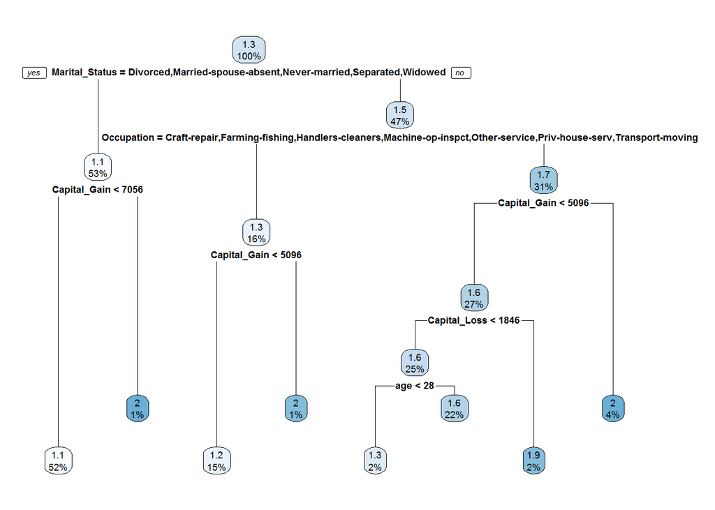

```r
rpart.plot(mytree)
```

#### Testing and Validation

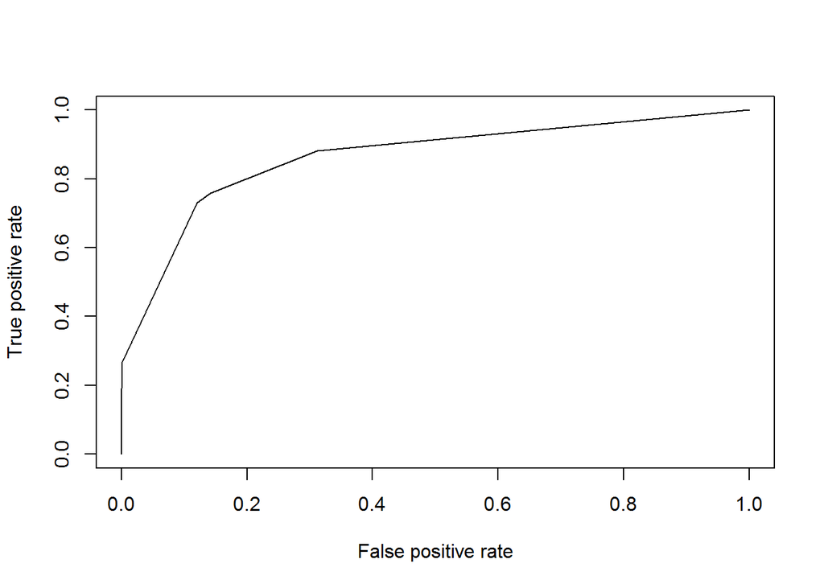

```r
actual <- na.omit(testing)$Over_50k
predictions <- predict(mytree, na.omit(testing))

mytreePredictions <- prediction(predictions, actual)

#ROC
mytreeROC <- performance(mytreePredictions, 'tpr','fpr')
plot(mytreeROC)
```

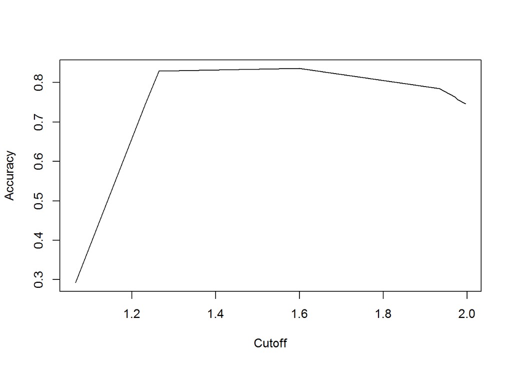

```r
#Accuracy
mytreeACC <- performance(mytreePredictions, 'acc')
plot(mytreeACC)
```

```r
#Area Under the Curve
mytreeAUC <- performance(mytreePredictions, 'auc')
mytreeAUC <- unlist(mytreeAUC@y.values)
mytreeAUC
```

```
## [1] 0.8624589
```

```r
cutoff <- unlist(mytreeROC@alpha.values)[which.max(unlist(mytreeROC@y.values)+ ( 1 - unlist(mytreeROC@x.values) )-1)]

predicted <- ifelse(predictions >= cutoff, 1, 0)
mytreeConfusion <- table(actual, predicted)
mytreeConfusion
```

```
##       predicted
## actual    0    1
##      0 3757  618
##      1  436 1373
```

```r
mytreeTruePos <- mytreeConfusion[2,2]/sum(mytreeConfusion[2,])
mytreeTrueNeg <- mytreeConfusion[1,1]/sum(mytreeConfusion[1,])
mytreeAccuracy <-sum(mytreeConfusion[2,2],mytreeConfusion[1,1])/sum(mytreeConfusion)

mytreeTruePos
```

```
## [1] 0.7589829
```

```r
mytreeTrueNeg
```

```
## [1] 0.8587429
```

```r
mytreeAccuracy
```

```
## [1] 0.8295602
```

## Conclusion

This census data contains some very interesting relationships between the target variable of earning over 50k per year, and demographic features. Attempts to train an SVM failed because the runtime for fitting was over 3 hours without any sign of finishing, even on a subset of features. This difficulty might be fixed by using the SVM implementation of caret, or the deprecated Rsofia package made by google which is supposed to be very fast.